Cuenca Zaldivar JN** j.cuenca.prof@ufv.es

# **ANALISIS ESTADISTICO**

Para el análisis estadístico se utilizó con el programa R Ver. 5.3.1.

El nivel de significación se estableció en p<0.05; el tamaño de efecto en las variables cuantitativas se definió como **r** 0.1 a 0.4 (pequeño), 0.4 a 0.6 (moderado) y >0.6 (grande) y **W de Kendall** <0.1 (pequeño), 0.1 a 0.3 (mediano) y >0.3 (grande); la fuerza de asociación en las variables categóricas **g de Cohen** se definió como <0.15 (pequeño), 0.15 a 0.25 (moderado) y >0.25 (grande) y, en el caso de la prueba Q de Cochran, cuando no fue posible, se calculó con el estadístico global $\eta^2_Q$ de Serlin et al (1982).

Se utilizó el test de Kolmogorov-Smirnoff con corrección de Lillieford que determinó la distribución no normal de las variables de resultado. Las variables cualitativas se describieron en valores y frecuencias absolutos y las variables cuantitativas con mediana y rango intercuartílico (IQR).

Las variables cuantitativas se analizaron utilizando la prueba del signo de Wilcoxon en aquellas en las que se realizaron dos mediciones pre-postratamiento, y la prueba de Friedman en aquellas en las que se realizaron tres mediciones pre-post-48 horas tras el tratamiento. Las variables de resultado cualitativas se analizaron con la prueba Q de Cochran; también se aplicó el test exacto de Fisher para determinar la existencia de diferencias en los niveles Wang en función del grupo de edad de los niños, y la prueba de Kruskal-Wallis en el caso de las puntuaciones numéricas de la escala. En las pruebas posthoc se aplicó la corrección de Bonferroni.

Cargamos los paquetes y la base de datos.

```r
library(readxl)
library(knitr)
library(kableExtra)
library(nortest)
library(tableone)
library(coin)
library(boot)
library(reshape2)
library(pgirmess)
library(DescTools)
library(rcompanion)
library(exact2x2)
library(plyr)
library(ggplot2)
library(gridExtra)
library(pwr)
library(effsize)
DATOS <- read_excel("F:/ESTUDIO BQ 18-19/DATOS.xlsx")
```

Comprobamos la estructura de los datos y recodificamos las variables en las que sea necesario, y creamos una nueva variable agrupando los rangos de edad de los niños. Además revisamos la presencia de valores perdidos comprobándose la existencia de un pequeño número de ellos.

```r
str(DATOS)
```

```
## Classes 'tbl_df', 'tbl' and 'data.frame':    265 obs. of  35 variables:
##  $ ID                 : num  1 2 3 4 5 6 7 8 9 10 ...
##  $ 6_months           : chr  "More" "More" "More" "More" ...
##  $ Center             : num  2 2 2 2 2 2 2 2 1 2 ...
##  $ Age                : num  6.15 6.9 6.4 11.13 11.13 ...
##  $ Height             : num  68 68 71 73 69 68 71 78 64 76 ...
##  $ Weight             : num  7.78 9.11 9 8 8.5 8.2 8 7.7 7.1 9.8 ...
##  $ Brothers           : chr  "School" "No" "No" "Kindergarten" ...
##  $ Tobacco            : chr  "Yes" "No" "Yes" "No" ...
##  $ Kindergarten       : chr  "Yes" "Yes" "Yes" "No" ...
##  $ Medication         : chr  "Ventolin" "Ventolin" "Nothing" "Nothing" ...
##  $ Associated_Pat     : chr  "Atopic skin and premature" "Nothing" "Nothing" "Premature" ...
##  $ Med_Consultation   : chr  "1st episode" "1st episode" "1st episode" "Exit income VRS+" ...
##  $ Pre_SatO2          : num  96 98 99 98 100 98 96 96 97 97 ...
##  $ Post_SatO2         : num  99 99 100 100 100 100 98 99 98 98 ...
```

[output cut: 21 more lines]

```r
DATOS$Age <- as.numeric(DATOS$Age)
DATOS$`6_months` <- factor(DATOS$`6_months`)
DATOS$Center <- factor(DATOS$Center)
DATOS$Brothers <- factor(DATOS$Brothers)
DATOS$Tobacco <- factor(DATOS$Tobacco)
DATOS$Kindergarten <- factor(DATOS$Kindergarten)
DATOS$Medication <- factor(DATOS$Medication)
DATOS$Associated_Pat <- factor(DATOS$Associated_Pat)
DATOS$ Med_Consultation <- factor(DATOS$ Med_Consultation)
DATOS$Pre_Retraction <- factor(DATOS$Pre_Retraction)
DATOS$Post_Retraction <- factor(DATOS$Post_Retraction)
DATOS$`48h_Retraction` <- factor(DATOS$`48h_Retraction`)
DATOS$Pre_Wheezing <- factor(DATOS$Pre_Wheezing)
DATOS$Post_Wheezing <- factor(DATOS$Post_Wheezing)
DATOS$`48h_Wheezing` <- factor(DATOS$`48h_Wheezing`)
DATOS$Pre_Gral_Condition <- factor(DATOS$Pre_Gral_Condition)
DATOS$Post_Gral_Condition <- factor(DATOS$Post_Gral_Condition)
DATOS$`48h_Gral_Condition` <- factor(DATOS$`48h_Gral_Condition`)
DATOS$Pre_Wang_Level <- factor(DATOS$Pre_Wang_Level)
DATOS$Post_Wang_Level <- factor(DATOS$Post_Wang_Level)
DATOS$`48h_Wang_Level` <- factor(DATOS$`48h_Wang_Level`)
DATOS$`Adverse events` <- factor(DATOS$`Adverse events`)
DATOS$Months <- as.numeric(DATOS$Age)
DATOS$Months[DATOS$Months>=9] <- "9 to 12 months"
DATOS$Months[DATOS$Months>=4 & DATOS$Months<9] <- "4 to 8 months"
DATOS$Months[DATOS$Months<4] <- "0 to 3 months"
DATOS$Months <- factor(DATOS$Months)
str(DATOS)
```

```
## Classes 'tbl_df', 'tbl' and 'data.frame':    265 obs. of  36 variables:
##  $ ID                 : num  1 2 3 4 5 6 7 8 9 10 ...
##  $ 6_months           : Factor w/ 2 levels "Less","More": 2 2 2 2 2 2 2 2 1 2 ...
##  $ Center             : Factor w/ 4 levels "1","2","3","4": 2 2 2 2 2 2 2 2 1 2 ...
##  $ Age                : num  6.15 6.9 6.4 11.13 11.13 ...
##  $ Height             : num  68 68 71 73 69 68 71 78 64 76 ...
##  $ Weight             : num  7.78 9.11 9 8 8.5 8.2 8 7.7 7.1 9.8 ...
##  $ Brothers           : Factor w/ 4 levels "At home","Kindergarten",..: 4 3 3 2 2 4 3 3 4 3 ...
##  $ Tobacco            : Factor w/ 2 levels "No","Yes": 2 1 2 1 1 1 1 1 2 1 ...
##  $ Kindergarten       : Factor w/ 2 levels "No","Yes": 2 2 2 1 1 2 2 2 2 2 ...
##  $ Medication         : Factor w/ 2 levels "Nothing","Ventolin": 2 2 1 1 1 2 2 2 2 1 ...
##  $ Associated_Pat     : Factor w/ 7 levels "Atopic skin",..: 2 3 3 4 5 3 3 3 3 3 ...
##  $ Med_Consultation   : Factor w/ 3 levels "1st episode",..: 1 1 1 3 3 1 1 1 1 1 ...
##  $ Pre_SatO2          : num  96 98 99 98 100 98 96 96 97 97 ...
##  $ Post_SatO2         : num  99 99 100 100 100 100 98 99 98 98 ...
```

[output cut: 22 more lines]

```r
m <- as.data.frame(sapply(DATOS, function(x) sum(is.na(x))))
colnames(m) <- "Perdidos"
m$Variable <- rownames(m)
m <- m[ , c(2, 1)]
m <- m[m$Perdidos > 0, ]
kable(m,"html", caption = "Valores perdidos") %>% kable_styling(full_width = F)
```

Valores perdidos

|  | Variable | Perdidos |
| --- | --- | --- |
| Post_SatO2 | Post_SatO2 | 1 |
| Post_HR | Post_HR | 1 |
| 48h_RR | 48h_RR | 3 |
| 48h_Retraction | 48h_Retraction | 3 |
| 48h_Wheezing | 48h_Wheezing | 3 |
| 48h_Gral_Condition | 48h_Gral_Condition | 3 |
| 48h_Wang | 48h_Wang | 3 |
| 48h_Wang_Level | 48h_Wang_Level | 3 |

## **TAMAÑO MUESTRAL**

Calculamos el tamaño muestral del estudio con los datos referentes a la variable de resultado principal, la escala Wang numérica, aplicando un T test para muestras pareadas con los datos pre-postratamiento y pretratamiento-seguimiento a las 48 horas utilizando los primeros 50 niños reclutados.

```r
d <- DATOS[c(1:50), ]
a <- cohen.d(d$Pre_Wang, d$Post_Wang, paired=TRUE)#tamaño de efecto
c <- pwr.t.test(d=a$estimate, power=.8, sig.level=.05, type="paired", alternative="two.sided")
a <- cohen.d(d$Pre_Wang, d$`48h_Wang`, paired=TRUE, na.rm = TRUE)#tamaño de efecto, teniendo en cuenta los valores perdidos en la variable 48h_Wang
t <- pwr.t.test(d=a$estimate, power=.8, sig.level=.05, type="paired", alternative="two.sided")
```

Aceptando una potencia del 80% y un riesgo $\alpha$= 0.05, se necesitan 5 pacientes por grupo (con un tamaño de efecto de 1.627) cuando comparamos las variables **Pre_Wang** y **Post_Wang**, y 5 pacientes por grupo (con un tamaño de efecto de 1.713) cuando comparamos las variables **Pre_Wang** y **48h_Wang**.

Calculamos la potencia final del estudio con los datos referentes a la variable de resultado principal, la escala Wang numérica, aplicando un T test para muestras pareadas con los datos pre-postratamiento y pretratamiento-seguimiento a las 48 horas.

```r
a <- cohen.d(DATOS$Pre_Wang, DATOS$Post_Wang, paired=TRUE)#tamaño de efecto
c <- pwr.t.test(n=265, d=a$estimate, sig.level=.05, type="paired", alternative="two.sided")
a <- cohen.d(DATOS$Pre_Wang, DATOS$`48h_Wang`, paired=TRUE, na.rm = TRUE)#tamaño de efecto, teniendo en cuenta los valores perdidos en la variable 48h_Wang
t <- pwr.t.test(n=265, d=a$estimate, sig.level=.05, type="paired", alternative="two.sided")
```

Con los 265 sujetos la potencia es del 100% cuando comparamos las variables **Pre_Wang** y **Post_Wang**, y del 100% cuando comparamos las variables **Pre_Wang** y **48h_Wang**, aceptando en ambos casos un riesgo $\alpha$= 0.05.

## **PRUEBA DE NORMALIDAD**

Realizamos el test de Kolmogorov-Smirnov con corrección de Lillieford sobre las variables cuantitativas que determina la distribución no normal de las mismas.

```r
d <- do.call(rbind, lapply(DATOS[c(4:6, 13:19, 29, 31, 33)], function(x) lillie.test(x)[c("statistic","p.value")]))
colnames(d) [1] <- "W"
colnames(d) [2] <- "p"
d[] <- lapply(d, formatC, digits=3, format="f")
d <- as.data.frame(d[])
d <- d[d$p >= 0.05, ]#mostramos solo las variables normales
kable(d, "html") %>% kable_styling(full_width = F)
```

| W | p |
| --- | --- |

## **DESCRIPTIVOS**

A continuación se muestra la tabla con los descriptivos basales.

```r
myvars <- c("6_months", "Age", "Height", "Weight", "Brothers", "Tobacco", "Kindergarten", "Medication", "Associated_Pat", "Med_Consultation", "Months")
nonormal <- c("Age", "Height", "Weight")
catvars <- c("6_months", "Center", "Brothers", "Tobacco", "Kindergarten", "Medication", "Associated_Pat", "Med_Consultation", "Months")
Tabla <- CreateTableOne(vars = myvars, factorVars = catvars, includeNA = TRUE, data = DATOS)
a <- print(Tabla, nonnormal = nonormal, showAllLevels = TRUE)
```

Datos basales clínicos y demográficos

|  | level | Overall |
| --- | --- | --- |
| n |  | 265 |
| 6_months (%) | Less | 100 (37.7) |
|  | More | 165 (62.3) |
| Age (median [IQR]) |  | 6.60 [4.30, 9.20] |
| Height (median [IQR]) |  | 68.00 [61.00, 72.00] |
| Weight (median [IQR]) |  | 7.80 [6.50, 8.70] |
| Brothers (%) | At home | 10 ( 3.8) |
|  | Kindergarten | 68 (25.7) |
|  | No | 83 (31.3) |
|  | School | 104 (39.2) |
| Tobacco (%) | No | 200 (75.5) |
|  | Yes | 65 (24.5) |
| Kindergarten (%) | No | 141 (53.2) |
|  | Yes | 124 (46.8) |
| Medication (%) | Nothing | 58 (21.9) |
|  | Ventolin | 207 (78.1) |
| Associated_Pat (%) | Atopic skin | 11 ( 4.2) |
|  | Atopic skin and premature | 1 ( 0.4) |
|  | Nothing | 175 (66.0) |
|  | Premature | 13 ( 4.9) |
|  | Premature and RGE | 2 ( 0.8) |
|  | RGE | 61 (23.0) |
|  | RGE and atopic dermatitis | 2 ( 0.8) |
| Med_Consultation (%) | 1st episode | 213 (80.4) |
|  | Exit income VRS- | 15 ( 5.7) |
|  | Exit income VRS+ | 37 (14.0) |
| Months (%) | 0 to 3 months | 51 (19.2) |
|  | 4 to 8 months | 135 (50.9) |
|  | 9 to 12 months | 79 (29.8) |

## **CONTRASTES DE HIPOTESIS**

### **VARIABLES CUANTITATIVAS**

Seguidamente mostramos los descriptivos con las variables de resultado.

```r
myvars <- c("Pre_SatO2", "Post_SatO2", "Pre_HR", "Post_HR", "Pre_RR", "Post_RR",
"48h_RR", "Pre_Wang", "Post_Wang", "48h_Wang")
nonormal <- c("Pre_SatO2", "Post_SatO2", "Pre_HR", "Post_HR", "Pre_RR", "Post_RR",
"48h_RR", "Pre_Wang", "Post_Wang", "48h_Wang")
Tabla <- CreateTableOne(vars = myvars, includeNA = TRUE, data = DATOS)
a <- print(Tabla, nonnormal = nonormal, showAllLevels = TRUE)
```

Variables de resultado

|  | level | Overall |
| --- | --- | --- |
| n |  | 265 |
| Pre_SatO2 (median [IQR]) |  | 97.00 [96.00, 98.00] |
| Post_SatO2 (median [IQR]) |  | 99.00 [98.00, 99.00] |
| Pre_HR (median [IQR]) |  | 140.00 [127.00, 155.00] |
| Post_HR (median [IQR]) |  | 142.00 [131.75, 166.25] |
| Pre_RR (median [IQR]) |  | 47.00 [41.00, 54.00] |
| Post_RR (median [IQR]) |  | 35.00 [29.00, 41.00] |
| 48h_RR (median [IQR]) |  | 28.00 [26.00, 31.75] |
| Pre_Wang (median [IQR]) |  | 3.00 [1.00, 4.00] |
| Post_Wang (median [IQR]) |  | 1.00 [0.00, 1.00] |
| 48h_Wang (median [IQR]) |  | 0.00 [0.00, 0.00] |

#### **PRUEBA DE WILCOXON: SatO<sub>2</sub>**

Se comprueba como hay diferencias significativas en la SatO<sub>2</sub> pre-postratamiento.

```r
wilcoxsign_test(DATOS$Post_SatO2 ~ DATOS$Pre_SatO2, distribution = "exact")
```

```
##
##  Exact Wilcoxon-Pratt Signed-Rank Test
##
## data:  y by x (pos, neg)
##   stratified by block
## Z = 14.034, p-value < 2.2e-16
## alternative hypothesis: true mu is not equal to 0
```

```r
a <- wilcox.test(DATOS$Post_SatO2, DATOS$Pre_SatO2, conf.int = TRUE, paired = TRUE)
a$estimate#estimación
```

```
## (pseudo)median
##       2.000066
```

```r
a$conf.int#IC95%
```

```
## [1] 2.000049 2.499968
## attr(,"conf.level")
## [1] 0.95
```

```r
d <- DATOS[c(13, 14)]
d <- melt(d, ID= c("Pre_SatO2", "Post_SatO2"))
wilcoxonPairedR(x = d$value, g = d$variable, ci = TRUE, R = 100)#r IC95%
```

```
##       r lower.ci upper.ci
## 1 0.862    0.844    0.873
```

#### **PRUEBA DE WILCOXON: FRECUENCIA CARDIACA**

Se comprueba como hay diferencias significativas en la frecuencia cardíaca pre-postratamiento.

```r
wilcoxsign_test(DATOS$Post_HR ~ DATOS$Pre_HR, distribution = "exact")
```

```
##
##  Exact Wilcoxon-Pratt Signed-Rank Test
##
## data:  y by x (pos, neg)
##   stratified by block
## Z = 3.2649, p-value = 0.001041
## alternative hypothesis: true mu is not equal to 0
```

```r
a <- wilcox.test(DATOS$Post_HR, DATOS$Pre_HR, conf.int = TRUE, paired = TRUE)
a$estimate#estimación
```

```
## (pseudo)median
##       3.500005
```

```r
a$conf.int#IC95%
```

```
## [1] 1.499957 6.000017
## attr(,"conf.level")
## [1] 0.95
```

```r
d <- DATOS[c(15, 16)]
d <- melt(d, ID= c("Pre_SatO2", "Post_SatO2"))
wilcoxonPairedR(x = d$value, g = d$variable, ci = TRUE, R = 100)#r IC95%
```

```
##       r lower.ci upper.ci
## 1 0.201   0.0869    0.356
```

#### **PRUEBA DE FRIEDMAN: FRECUENCIA RESPIRATORIA**

Se comprueba como hay diferencias significativas en la frecuencia respiratoria a lo largo de los tres momentos de medición.

```r
d <- DATOS[c(1, 17:19)]
d <- melt(d, id = "ID")
friedman.test(d$value, d$variable, d$ID)
```

```
##
##  Friedman rank sum test
##
## data:  d$value, d$variable and d$ID
## Friedman chi-squared = 477.17, df = 2, p-value < 2.2e-16
```

```r
source('http://www2.ntupsychology.net/seriousstats/SeriousStatsAllfunctions.txt')#cargamos la funcion para calcular el IC de Cousineau-Morey intrasujetos
#la función no admite valores perdidos por lo que los sustituimos con la mediana dado que las variables no tienen una distribución normal
de <- DATOS[c(1, 17:19)]
de$Post_RR[is.na(de$Post_RR)] <- median(de$Post_RR, na.rm=TRUE)
de$`48h_RR`[is.na(de$`48h_RR`)] <- median(de$`48h_RR`, na.rm=TRUE)
cm.ci(de[2:4])#IC95%
```

```
##            lower    upper
## Pre_RR  46.60359 47.38886
## Post_RR 34.88073 35.54946
## 48h_RR  28.72247 29.55678
```

La prueba post hoc, tanto con corrección de Bonferroni como con el test de Tukey muestra diferencias significativas entre todos los momentos de medición entre si.

```r
pairwise.wilcox.test(d$value, d$variable, p.adj = "bonferroni", exact = FALSE, paired = TRUE)
```

```
##
##  Pairwise comparisons using Wilcoxon signed rank test
##
## data:  d$value and d$variable
##
##         Pre_RR Post_RR
## Post_RR <2e-16 -
## 48h_RR  <2e-16 <2e-16
##
## P value adjustment method: bonferroni
```

```r
friedmanmc(d$value, d$variable, d$ID)
```

```
## Multiple comparisons between groups after Friedman test
## p.value: 0.05
## Comparisons
##                obs.dif critical.dif difference
## Pre_RR-Post_RR   292.5     55.11355       TRUE
## Pre_RR-48h_RR    490.5     55.11355       TRUE
## Post_RR-48h_RR   198.0     55.11355       TRUE
```

```r
set.seed(1)
XT = xtabs(value ~ variable + ID, data = d)
KendallW(XT, correct = TRUE, test = TRUE, na.rm = TRUE)#tamaño de efecto
```

```
##
##  Kendall's coefficient of concordance Wt
##
## data:  XT
## Kendall chi-squared = 483.1, df = 2, subjects = 3, raters = 265,
## p-value < 2.2e-16
## alternative hypothesis: Wt is greater 0
## sample estimates:
##        Wt
## 0.9115107
```

#### **PRUEBA DE FRIEDMAN: ESCALA WANG**

Se comprueba como hay diferencias significativas en las puntuaciones de la escala Wang a lo largo de los tres momentos de medición.

```r
d <- melt(DATOS[c(1, 29, 31, 33)], id = "ID")
friedman.test(d$value, d$variable, d$ID)
```

```
##
##  Friedman rank sum test
##
## data:  d$value, d$variable and d$ID
## Friedman chi-squared = 480.23, df = 2, p-value < 2.2e-16
```

```r
#la función para calcular el IC de Cousineau-Morey no admite valores perdidos por lo que los sustituimos con la mediana dado que las variables no tienen una distribución normal
de <- DATOS[c(1, 29, 31, 33)]
de$`48h_Wang`[is.na(de$`48h_Wang`)] <- median(de$`48h_Wang`, na.rm=TRUE)
cm.ci(de[2:4])#IC95%
```

```
##                 lower     upper
## Pre_Wang   2.76775383 2.9454537
## Post_Wang  0.66968091 0.7491870
## 48h_Wang  -0.02794624 0.1260595
```

La prueba post hoc, tanto con corrección de Bonferroni como con el test de Tukey muestra diferencias significativas entre todos los momentos de medición entre si.

```r
pairwise.wilcox.test(d$value, d$variable, p.adj = "bonferroni", exact = FALSE, paired = TRUE)
```

```
##
##  Pairwise comparisons using Wilcoxon signed rank test
##
## data:  d$value and d$variable
##
##           Pre_Wang Post_Wang
## Post_Wang <2e-16   -
## 48h_Wang  <2e-16   <2e-16
##
## P value adjustment method: bonferroni
```

```r
friedmanmc(d$value, d$variable, d$ID)
```

```
## Multiple comparisons between groups after Friedman test
## p.value: 0.05
## Comparisons
##                    obs.dif critical.dif difference
## Pre_Wang-Post_Wang   329.0     55.11355       TRUE
## Pre_Wang-48h_Wang    449.5     55.11355       TRUE
## Post_Wang-48h_Wang   120.5     55.11355       TRUE
```

```r
set.seed(1)
XT = xtabs(value ~ variable + ID, data = d)
KendallW(XT, correct = TRUE, test = TRUE, na.rm = TRUE)#tamaño de efecto
```

```
##
##  Kendall's coefficient of concordance Wt
##
## data:  XT
## Kendall chi-squared = 485.81, df = 2, subjects = 3, raters = 265,
## p-value < 2.2e-16
## alternative hypothesis: Wt is greater 0
## sample estimates:
##       Wt
## 0.916628
```

### **VARIABLES CUALITATIVAS**

Seguidamente mostramos los descriptivos con las variables de resultado.

```r
catvars <- c("Pre_Retraction", "Post_Retraction", "48h_Retraction", "Pre_Wheezing", "Post_Wheezing", "48h_Wheezing", "Pre_Gral_Condition", "Post_Gral_Condition", "48h_Gral_Condition", "Pre_Wang_Level", "Post_Wang_Level", "48h_Wang_Level")
Tabla <- CreateCatTable(vars = catvars, includeNA = TRUE, data = DATOS)
a <- print(Tabla, showAllLevels = TRUE)
```

Variables de resultado

|  | level | Overall |
| --- | --- | --- |
| n |  | 265 |
| Pre_Retraction (%) | No | 141 ( 53.2) |
|  | Yes | 124 ( 46.8) |
| Post_Retraction (%) | No | 245 ( 92.5) |
|  | Yes | 20 ( 7.5) |
| 48h_Retraction (%) | No | 262 ( 98.9) |
|  | NA | 3 ( 1.1) |
| Pre_Wheezing (%) | No | 96 ( 36.2) |
|  | Yes | 169 ( 63.8) |
| Post_Wheezing (%) | No | 239 ( 90.2) |
|  | Yes | 26 ( 9.8) |
| 48h_Wheezing (%) | No | 262 ( 98.9) |
|  | NA | 3 ( 1.1) |
| Pre_Gral_Condition (%) | Good | 265 (100.0) |
| Post_Gral_Condition (%) | Good | 265 (100.0) |
| 48h_Gral_Condition (%) | Good | 262 ( 98.9) |
|  | NA | 3 ( 1.1) |
| Pre_Wang_Level (%) | Mild | 157 ( 59.2) |
|  | Moderate | 108 ( 40.8) |
| Post_Wang_Level (%) | Mild | 133 ( 50.2) |
|  | Normal | 132 ( 49.8) |
| 48h_Wang_Level (%) | Mild | 15 ( 5.7) |
|  | Normal | 247 ( 93.2) |
|  | NA | 3 ( 1.1) |

#### **PRUEBA Q DE COCHRAN: RETRACCION**

Se comprueba como hay cambios significativos en la proporción de pacientes con retracción a lo largo de los tres momentos de medición.

```r
d <- melt(DATOS[c(1, 20:22)], id = "ID")
d$ID <- factor(d$ID)
d$value <- as.numeric(d$value == "Yes")
d$value[is.na(d$value)] <- median(d$value, na.rm=TRUE)#el test no admite valores perdidos por lo que los sustituimos por la mediana que, en este caso, da un número entero en el puesto 398 de la variable value
symmetry_test(value ~ variable | ID, data = d, teststat = "quad")
```

```
##
##  Asymptotic General Symmetry Test
##
## data:  value by
##   variable (Pre_Retraction, Post_Retraction, 48h_Retraction)
##   stratified by ID
## chi-squared = 214.45, df = 2, p-value < 2.2e-16
```

La prueba post hoc muestra diferencias entre todas las mediciones y entre la primera y la última mediciones.

```r
pairwiseMcnemar(value ~ variable | ID, data = d, test = "mcnemar", method = "bonferroni", digits = 3)
```

```
## $Test.method
##      Test
## 1 mcnemar
##
## $Adustment.method
##       Method
## 1 bonferroni
##
## $Pairwise
##                             Comparison chi.sq df  p.value p.adjust
## 1 Pre_Retraction - Post_Retraction = 0    104  1 2.02e-24 6.06e-24
## 2  Pre_Retraction - 48h_Retraction = 0    124  1 8.42e-29 2.53e-28
## 3 Post_Retraction - 48h_Retraction = 0     20  1 7.74e-06 2.32e-05
```

No es posible calcular los parámetros entre la primera y la última sesión, ya que a las 48 horas ningún paciente presentaba retracción, por lo que calculamos el tamaño de efecto global $\eta^2_Q$.

```r
e <- symmetry_test(value ~ variable | ID, data = d, teststat = "quad")
c <- DATOS[c(20:22)]
myMatrix <- cbind(c$Pre_Retraction, c$Post_Retraction, c$`48h_Retraction`)
b <- dim(myMatrix)[1]
k <- dim(myMatrix)[2]
e@statistic@teststatistic/(b*(k-1))
```

```
## [1] 0.4046257
```

#### **PRUEBA Q DE COCHRAN: SIBILANCIAS**

Se comprueba como hay cambios significativos en la proporción de pacientes con sibilancias a lo largo de los tres momentos de medición.

```r
d <- melt(DATOS[c(1, 23:25)], id = "ID")
d$ID <- factor(d$ID)
d$value <- as.numeric(d$value == "Yes")
d$value[is.na(d$value)] <- median(d$value, na.rm=TRUE)#el test no admite valores perdidos por lo que los sustituimos por la mediana que, en este caso, da un número entero en el puesto 398 de la variable value
symmetry_test(value ~ variable | ID, data = d, teststat = "quad")
```

```
##
##  Asymptotic General Symmetry Test
##
## data:  value by
##   variable (Pre_Wheezing, Post_Wheezing, 48h_Wheezing)
##   stratified by ID
## chi-squared = 294, df = 2, p-value < 2.2e-16
```

La prueba post hoc muestra diferencias entre todas las mediciones y entre la primera y la última mediciones.

```r
pairwiseMcnemar(value ~ variable | ID, data = d, test = "mcnemar", method = "bonferroni", digits = 3)
```

```
## $Test.method
##      Test
## 1 mcnemar
##
## $Adustment.method
##       Method
## 1 bonferroni
##
## $Pairwise
##                         Comparison chi.sq df  p.value p.adjust
## 1 Pre_Wheezing - Post_Wheezing = 0    143  1 5.88e-33 1.76e-32
## 2  Pre_Wheezing - 48h_Wheezing = 0    169  1 1.22e-38 3.66e-38
## 3 Post_Wheezing - 48h_Wheezing = 0     26  1 3.41e-07 1.02e-06
```

No es posible calcular los parámetros entre la primera y la última sesión, ya que a las 48 horas ningún paciente presentaba retracción, por lo que calculamos el tamaño de efecto global $\eta^2_Q$.

```r
e <- symmetry_test(value ~ variable | ID, data = d, teststat = "quad")
c <- DATOS[c(23:25)]
myMatrix <- cbind(c$Pre_Wheezing, c$Post_Wheezing, c$`48h_Wheezing`)
b <- dim(myMatrix)[1]
k <- dim(myMatrix)[2]
e@statistic@teststatistic/(b*(k-1))
```

```
## [1] 0.554717
```

#### **PRUEBA Q DE COCHRAN: CONDICION GENERAL**

Todos los paciente presentan un nivel **Good** en todas las mediciones.

#### **PRUEBA Q DE COCHRAN: NIVELES WANG**

Se comprueba como hay cambios significativos en la proporción de niveles de la escala Wang a lo largo de los tres momentos de medición.

```r
d <- melt(DATOS[c(1, 30, 32, 34)], id = "ID")
d$ID <- factor(d$ID)
d$value <- revalue(d$value, c("Normal"="0", "Mild"="1", "Moderate"="2"))
d$value <- as.numeric(d$value)
d$value[is.na(d$value)] <- median(d$value, na.rm=TRUE)#el test no admite valores perdidos por lo que los sustituimos por la mediana que, en este caso, da un número entero en el puesto 398 de la variable value
symmetry_test(value ~ variable | ID, data = d, teststat = "quad")
```

```
##
##  Asymptotic General Symmetry Test
##
## data:  value by
##   variable (Pre_Wang_Level, Post_Wang_Level, 48h_Wang_Level)
##   stratified by ID
## chi-squared = 424.25, df = 2, p-value < 2.2e-16
```

La prueba post hoc muestra diferencias entre todas las mediciones y entre la primera y la última mediciones.

```r
pairwiseMcnemar(value ~ variable | ID, data = d, test = "mcnemar", method = "bonferroni", digits = 3)
```

```
## $Test.method
##      Test
## 1 mcnemar
##
## $Adustment.method
##       Method
## 1 bonferroni
##
## $Pairwise
##                             Comparison chi.sq df  p.value p.adjust
## 1 Pre_Wang_Level - Post_Wang_Level = 0    121  1 3.82e-28 1.15e-27
## 2  Pre_Wang_Level - 48h_Wang_Level = 0    152  1 6.34e-35 1.90e-34
## 3 Post_Wang_Level - 48h_Wang_Level = 0    109  1  1.4e-25 4.20e-25
```

Calculamos los parámetros entre la primera y la última sesión.

```r
set.seed(1)
mcnemar.exact(table(DATOS$Pre_Wang_Level, DATOS$`48h_Wang_Level`))
```

```
##
##  Exact McNemar test (with central confidence intervals)
##
## data:  table(DATOS$Pre_Wang_Level, DATOS$`48h_Wang_Level`)
## b = 152, c = 11, p-value < 2.2e-16
## alternative hypothesis: true odds ratio is not equal to 1
## 95 percent confidence interval:
##   7.507803 28.268012
## sample estimates:
## odds ratio
##   13.81818
```

```r
a <- cohenG(table(DATOS$Pre_Wang_Level, DATOS$`48h_Wang_Level`))
a$Global.statistics#tamaño de efecto
```

```
##   Dimensions   OR     P     g
## 1      2 x 2 13.8 0.933 0.433
```

```r
Function <- function(d, i){
d2 <- d[i,]
return(as.numeric(cohenG(d2)$Global.statistics["g"]))
}
a <- as.matrix(table(DATOS$Pre_Wang_Level, DATOS$`48h_Wang_Level`))
Boot <- boot(a, Function, R=100)
boot.ci(Boot, conf = 0.95, type = "perc")#IC95%
```

```
## BOOTSTRAP CONFIDENCE INTERVAL CALCULATIONS
## Based on 100 bootstrap replicates
##
## CALL :
## boot.ci(boot.out = Boot, conf = 0.95, type = "perc")
##
## Intervals :
## Level     Percentile
## 95%   ( 0.396,  0.474 )
## Calculations and Intervals on Original Scale
## Some percentile intervals may be unstable
```

#### NIVELES WANG EN FUNCION DE LA EDAD CATEGORIZADA

Se comprueba si existen diferencias significativas en las categorías postratamiento y a las 48 horas de la escala Wang en función de los rangos de edad de los niños.

El test de Fisher muestra diferencias basales significativas (p<0.05) entre los tres grupos de edad, por lo que las diferencias halladas en la sesión postratamiento no son comparables.

```r
df <- DATOS
colnames(df)[34] <- "Two_days_Wang_Level"
multi.xtabs <- function(df, vars, group.var, ...) {
sapply(simplify = FALSE, vars,
function(var) {
formula <- as.formula(paste("~", var, "+", group.var))
xtabs(data = df, formula, ...)
}
)
}
list.of.xtabs <- multi.xtabs(df = df, vars = c("Pre_Wang_Level", "Post_Wang_Level", "Two_days_Wang_Level"), group.var = "Months")
fisher <- lapply(list.of.xtabs, fisher.test)
p <- sapply(fisher, "[[", "p.value")
x <- as.data.frame(p)
x$p <- round(x$p, 3)
kable(x, "html")%>% kable_styling(full_width = F)
```

|  | p |
| --- | --- |
| Pre_Wang_Level | 0.017 |
| Post_Wang_Level | 0.000 |
| Two_days_Wang_Level | 0.826 |

La prueba de Kruskal-Wallis muestra diferencias basales significativas (p<0.05) entre los tres grupos de edad, por lo que las diferencias halladas en la sesión postratamiento no son comparables.

```r
x <- lapply(df[,c("Pre_Wang_Level", "Post_Wang_Level", "Two_days_Wang_Level")], function(x) kruskal.test(x ~ df$Months))
z <- as.data.frame(do.call(rbind, x))
z <- z[c(1,3)]
z$statistic <- round(as.numeric(z$statistic), 3)
z$p.value <- round(as.numeric(z$p.value), 3)
colnames(z) <- c("W", "p")
kable(z, "html") %>% kable_styling(full_width = F)
```

|  | W | p |
| --- | --- | --- |
| Pre_Wang_Level | 7.960 | 0.019 |
| Post_Wang_Level | 25.004 | 0.000 |
| Two_days_Wang_Level | 0.605 | 0.739 |

# EVENTOS ADVERSOS

Se presenta la tabla de descriptivos con los eventos adversos que se han producido.

```r
catvars <- c("Adverse events")
Tabla <- CreateCatTable(vars = catvars, includeNA = TRUE, data = DATOS)
a <- print(Tabla, showAllLevels = TRUE)
```

|  | level | Overall |
| --- | --- | --- |
| n |  | 265 |
| Adverse events (%) | Epistasis | 2 ( 0.8) |
|  | No | 234 (88.3) |
|  | Petechia | 23 ( 8.7) |
|  | Vomit | 6 ( 2.3) |

# **RESULTADOS**

## **VARIABLES CUANTITATIVAS**

La muestra esta formada por 265 niños de unos 6.60 [4.30, 9.20] meses de edad, 68.00 [61.00, 72.00] cm de talla y un peso de 7.80 [6.50, 8.70] kg; la mayoría tomaba Ventolín (78.1%) y no tenían patologías asociadas (66.0%), siendo la presencia de RGE la más habitual (23.0%). Para la mayoría era la primera vez que acudían a consulta médica (80.4%).

La prueba de Friedman indicó cambios significativos en la frecuencia respiratoria a lo largo de los tres tiempos de evaluación (X<sup>2</sup>(2)=477.17, p<0.001), la prueba post hoc mostró que estas diferencias se producen tanto entre las sesiones pre-postratamiento como a las 48 horas (p<0.001), con una reducción progresiva de la misma (IC<sub>CM</sub>95% [46.603, 47.388], IC<sub>CM</sub>95% [34.88, 35.549], IC<sub>CM</sub>95% [28.722, 29.556] respectivamente) y un tamaño de efecto grande (W de Kendall=0.911, p<0.001).

La prueba de Friedman también indicó cambios significativos en la puntuación de la escala Wang a lo largo de los tres tiempos de evaluación (X<sup>2</sup>(2)=480.23, p<0.001), la prueba post hoc mostró que estas diferencias se producen tanto entre las sesiones pre-postratamiento como a las 48 horas (p<0.001), con una reducción progresiva de la misma (IC<sub>CM</sub>95% [2.76, 2.945], IC<sub>CM</sub>95% [0.669, 0.749], IC<sub>CM</sub>95% [-0.027, 0.126] respectivamente) y un tamaño de efecto grande (W de Kendall=0.916, p<0.001).

## **VARIABLES CUALITATIVAS**

La prueba Q de Cochran también mostró una asociación significativa en la proporción de pacientes sin sibilancias a lo largo de los tres tiempos de evaluación (X<sup>2</sup>(2)=294, p<0.001), las pruebas post hoc mostraron que estos cambios se producen tanto entre las sesiones pre-postratamiento como a las 48 horas (p<0.001) y con un aumento progresivo en la proporción de pacientes sin sibilancias (96 (36.2%), 239 (90.2%) y 262 (98.9%) respectivamente) y un tamaño de efecto $\eta^2_Q$=0.554.

Todos los pacientes presentaron una condición general de **Good** en todas las sesiones por lo que no se han producido cambios en la misma.

Finalmente, la prueba Q de Cochran también mostró una asociación significativa en los niveles de la escala Wang a lo largo de los tres tiempos de evaluación (X<sup>2</sup>(2)=424.25, p<0.001), la prueba post hoc mostró que estos cambios se producen tanto entre las sesiones pre-postratamiento como a las 48 horas (OR=13.818, IC95% [7.507, 28.268], p<0.001) con una reducción progresiva de los pacientes con un nivel **Mild** (157 (59.2%), 133 (50.2%) y 15 (5.7%) respectivamente) y un aumento de los que presentaron un nivel **Normal** (0 (0%), 132 (49.8%) y 247 (93.2%) respectivamente). El tamaño del efecto entre la primera y la última evaluación fue grande (g de Cohen=0.433, IC95% [0.396, 0.474]).

Finalmente se comprobó la presencia de diferencias significativas en las puntuaciones y categorías de la escala Wang en función de los grupos de edad de los niños. El test exacto de Fisher y la prueba de Kruskal-Wallis mostraron diferencias en la sesión postratamiento, sin embargo, la existencia de diferencias significativas basales impiden la comparación entre los tres grupos de edad.

# **GRAFICOS**

A continuación se muestran los gráficos con las variables cuyos resultados han resultado ser significativos.

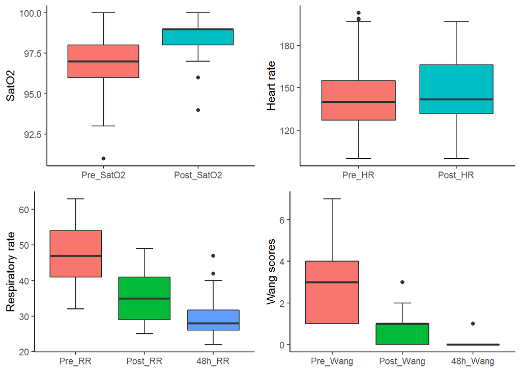

```r
d1 <- DATOS[c(1, 13, 14)]
d1 <- melt(d1, id = "ID")
p1 <- ggplot(d1, aes(x=variable, y=value, fill=variable)) +  guides(fill=FALSE) + stat_boxplot(geom ='errorbar', width = 0.25) + geom_boxplot(position=position_dodge(1))   + theme(legend.position="none") + labs(y = "SatO2") + theme_classic() + theme(axis.title.x = element_blank())
d1 <- DATOS[c(1, 15, 16)]
d1 <- melt(d1, id = "ID")
p2 <- ggplot(d1, aes(x=variable, y=value, fill=variable)) + guides(fill=FALSE) + stat_boxplot(geom ='errorbar', width = 0.25) + geom_boxplot(position=position_dodge(1)) + theme(legend.position="none") + labs(y = "Heart rate") + theme_classic() + theme(axis.title.x = element_blank())
d1 <- DATOS[c(1, 17:19)]
d1 <- melt(d1, id = "ID")
p3 <- ggplot(d1, aes(x=variable, y=value, fill=variable)) +  guides(fill=FALSE) + stat_boxplot(geom ='errorbar', width = 0.25) + geom_boxplot(position=position_dodge(1)) +   theme(legend.position="none") + labs(y = "Respiratory rate") + theme_classic() + theme(axis.title.x = element_blank())
d1 <- DATOS[c(1, 29, 31, 33)]
d1 <- melt(d1, id = "ID")
p4 <- ggplot(d1, aes(x=variable, y=value, fill=variable)) + guides(fill=FALSE) + stat_boxplot(geom ='errorbar', width = 0.25) + geom_boxplot(position=position_dodge(1)) + theme(legend.position="none") + labs(y = "Wang scores") + theme_classic() + theme(axis.title.x = element_blank())
p=rbind(c(1, 2), c(3, 4))
grid.arrange(p1, p2, p3, p4, layout_matrix=p)
```

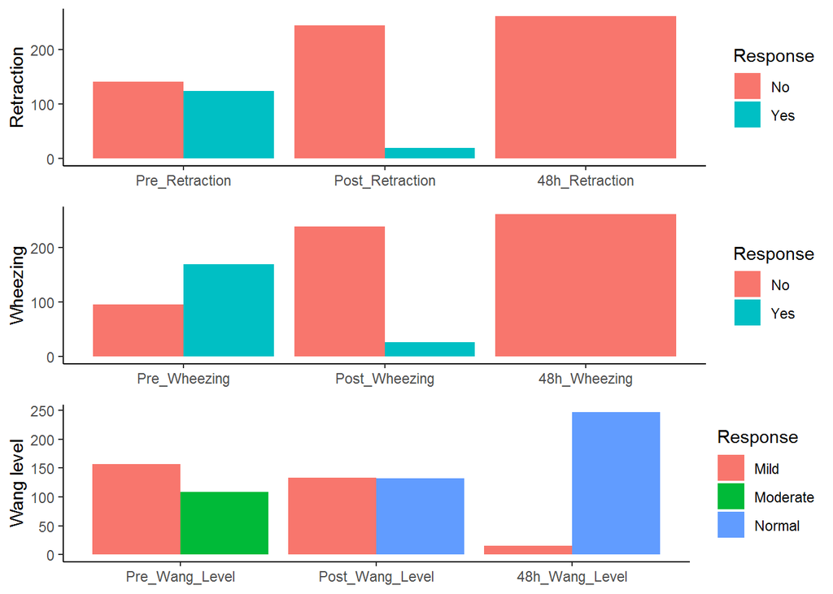

```r
setwd("F:/ESTUDIO BQ 18-19")#archivo de imagen para publicación
ggsave(file="Figure_2.eps", arrangeGrob(p1, p2, p3, p4, ncol = 2))
d1 <- DATOS[c(1, 20:22)]
d1 <- melt(d1, id = "ID")
colnames(d1) <- c("ID", "Retraction", "Response")
grup <- count(d1, c("Retraction", "Response"))
p5 <- ggplot(na.omit(grup), aes(x=Retraction, y=freq, fill=Response)) + geom_bar(stat="identity", position=position_dodge())+theme_classic()+theme(plot.title = element_blank(),   axis.title.x = element_blank())+labs(y = "Retraction")
d1 <- DATOS[c(1, 23:25)]
d1 <- melt(d1, id = "ID")
colnames(d1) <- c("ID", "Wheezing", "Response")
grup <- count(d1, c("Wheezing", "Response"))
p6 <- ggplot(na.omit(grup), aes(x=Wheezing, y=freq, fill=Response)) + geom_bar(stat="identity",  position=position_dodge()) + theme_classic() + theme(plot.title = element_blank(),   axis.title.x = element_blank()) + labs(y = "Wheezing")
d1 <- DATOS[c(1, 30, 32, 34)]
d1 <- melt(d1, id = "ID")
colnames(d1) <- c("ID", "Wang_level", "Response")
grup <- count(d1, c("Wang_level", "Response"))
p7 <- ggplot(na.omit(grup), aes(x=Wang_level, y=freq, fill=Response)) + geom_bar(stat="identity",  position=position_dodge()) + theme_classic() + theme(plot.title = element_blank(),   axis.title.x = element_blank()) + labs(y = "Wang level")
p=rbind(c(1), c(2), c(3))
grid.arrange(p5, p6, p7, layout_matrix=p)
```

```r
setwd("F:/ESTUDIO BQ 18-19")#archivo de imagen para publicación
ggsave(file="Figure_3.eps", arrangeGrob(p5, p6, p7, ncol = 1))
```